# MTH6139 Time Series

Coursework 1 – Template

Ismail Bin Hamid

Spring term 2025

# Section 1: Introduction

This project explores time series forecasting using Meta’s Prophet package in R. We will analyze the Mauna Loa CO₂ dataset, apply forecasting methods, and evaluate trends and seasonality.

## 1.1 CO2 Dataset Overview

co2 is a dataset of the Mauna Loa Atmospheric CO2 Concentration where it’s expressed in parts per million (ppm). It’s a time series of 468 observations; monthly from 1959 to 1997.

## 1.2 Project Purpose

The goal of this project is to analyze and forecast atmospheric CO₂ levels using Meta’s Prophet forecasting system. We will:

Explore historical trends and seasonality. Develop a forecasting model. Evaluate model performance. Discuss potential implications of our findings.

# Section 2: Data Preparation

## 2.1 Loading and Preprocessing the CO₂ Data

```r
# Load built-in CO₂ dataset
co2.df <- data.frame(
  ds = zoo::as.Date(as.yearmon(time(co2))),  # Convert time format
  y = as.numeric(co2)  # Convert to numeric values
)
```

```r
# Remove missing values if any
co2.df <- na.omit(co2.df)
```

```r
# View first few rows
head(co2.df)
```

```
##           ds      y
## 1 1959-01-01 315.42
## 2 1959-02-01 316.31
## 3 1959-03-01 316.50
## 4 1959-04-01 317.56
## 5 1959-05-01 318.13
## 6 1959-06-01 318.00
```

## 2.2 Summary Statistics

```r
summary(co2.df$y)  # Summary statistics
```

```
##    Min. 1st Qu.  Median    Mean 3rd Qu.    Max.
##   313.2   323.5   335.2   337.1   350.3   366.8
```

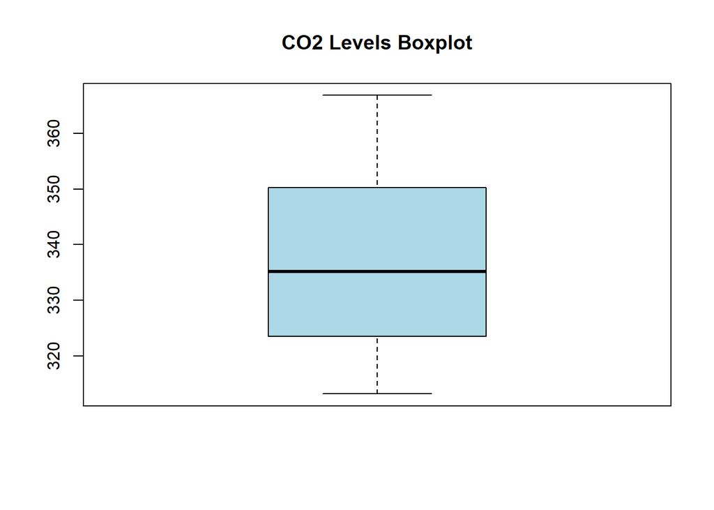

```r
boxplot(co2.df$y, main="CO2 Levels Boxplot", col="lightblue")
```

## 2.3 Raw Data Visualisation

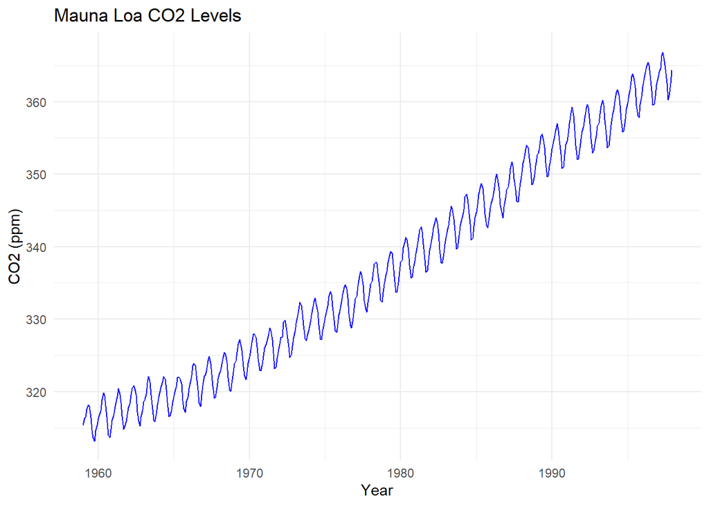

```r
# Plot raw CO₂ data
library(ggplot2)
ggplot(co2.df, aes(x = ds, y = y)) +
  geom_line(color = "blue") +
  labs(title = "Mauna Loa CO2 Levels", x = "Year", y = "CO2 (ppm)") +
  theme_minimal()
```

## 2.4 Interpretation

The CO₂ levels show a clear upward trend over time, reflecting the increase in global atmospheric CO₂ concentrations. There is also an annual seasonal pattern, likely due to natural processes such as plant respiration.

# Section 3: Prophet Forecasting Model

```r
# Load Prophet
library(prophet)
```

## 3.1 Training the Model

```r
# Fit the model
model <- prophet(co2.df)
```

```
## Disabling weekly seasonality. Run prophet with weekly.seasonality=TRUE to override this.
```

```
## Disabling daily seasonality. Run prophet with daily.seasonality=TRUE to override this.
```

## 3.2 Creating Future Time Periods

```r
# Create future dates for forecasting
future <- make_future_dataframe(model, periods = 12, freq = "month")
```

## 3.3 Predicting Future Values

```r
# Predict future values
forecast <- predict(model, future)
```

```r
# View the predictions
head(forecast)
```

```
##           ds    trend additive_terms additive_terms_lower additive_terms_upper
## 1 1959-01-01 315.3537    -0.07753751          -0.07753751          -0.07753751
## 2 1959-02-01 315.4387     0.59487739           0.59487739           0.59487739
## 3 1959-03-01 315.5155     1.23263039           1.23263039           1.23263039
## 4 1959-04-01 315.6005     2.46038945           2.46038945           2.46038945
## 5 1959-05-01 315.6828     3.02022342           3.02022342           3.02022342
## 6 1959-06-01 315.7678     2.35150786           2.35150786           2.35150786
##        yearly yearly_lower yearly_upper multiplicative_terms
## 1 -0.07753751  -0.07753751  -0.07753751                    0
## 2  0.59487739   0.59487739   0.59487739                    0
## 3  1.23263039   1.23263039   1.23263039                    0
## 4  2.46038945   2.46038945   2.46038945                    0
## 5  3.02022342   3.02022342   3.02022342                    0
## 6  2.35150786   2.35150786   2.35150786                    0
##   multiplicative_terms_lower multiplicative_terms_upper yhat_lower yhat_upper
## 1                          0                          0   314.7888   315.7510
## 2                          0                          0   315.5757   316.4849
## 3                          0                          0   316.2801   317.2067
## 4                          0                          0   317.6015   318.5337
## 5                          0                          0   318.2926   319.1529
## 6                          0                          0   317.6600   318.6020
##   trend_lower trend_upper     yhat
## 1    315.3537    315.3537 315.2762
## 2    315.4387    315.4387 316.0336
## 3    315.5155    315.5155 316.7481
## 4    315.6005    315.6005 318.0609
## 5    315.6828    315.6828 318.7030
## 6    315.7678    315.7678 318.1193
```

## 3.4 Forecast Visualisation

```r
# Plot forecast
dyplot.prophet(model, forecast)
```

[interactive chart not shown]

## 3.5 Interpretation

The forecast suggests that CO₂ levels will continue to rise if current trends persist. The shaded area represents the uncertainty interval of the predictions.

# Section 4: Seasonality & Trends

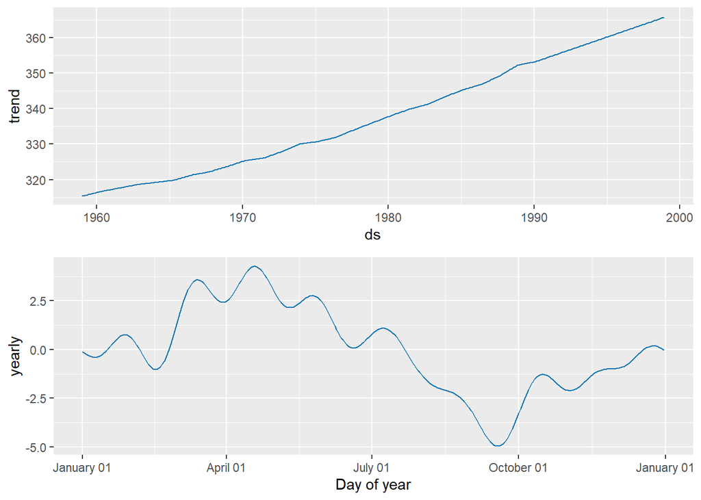

```r
# Plot seasonality components
prophet_plot_components(model, forecast)
```

## 4.1 Interpretation

**Trend:** Shows the long-term increase in CO₂ levels. **Yearly Seasonality:** Highlights regular seasonal patterns in CO₂ fluctuations.

# Section 5: Additional Analysis

## 5.1 Implementation of Linear Regression

```r
# Fit a linear regression model to check the growth trend
linear_model <- lm(y ~ ds, data = co2.df)

# Display regression summary
summary(linear_model)
```

```
##
## Call:
## lm(formula = y ~ ds, data = co2.df)
##
## Residuals:
##     Min      1Q  Median      3Q     Max
## -6.0413 -1.9469  0.0004  1.9106  6.5161
##
## Coefficients:
##              Estimate Std. Error t value Pr(>|t|)
## (Intercept) 3.260e+02  1.514e-01  2153.2   <2e-16 ***
## ds          3.580e-03  2.944e-05   121.6   <2e-16 ***
## ---
## Signif. codes:  0 '***' 0.001 '**' 0.01 '*' 0.05 '.' 0.1 ' ' 1
##
## Residual standard error: 2.619 on 466 degrees of freedom
## Multiple R-squared:  0.9694, Adjusted R-squared:  0.9694
## F-statistic: 1.478e+04 on 1 and 466 DF,  p-value: < 2.2e-16
```

## 5.2 Interpretation

The regression analysis provides insight into the overall growth rate of CO₂ levels. A significant positive coefficient for ds confirms that CO₂ concentrations are increasing over time

## 5.3 Boxplot Representation

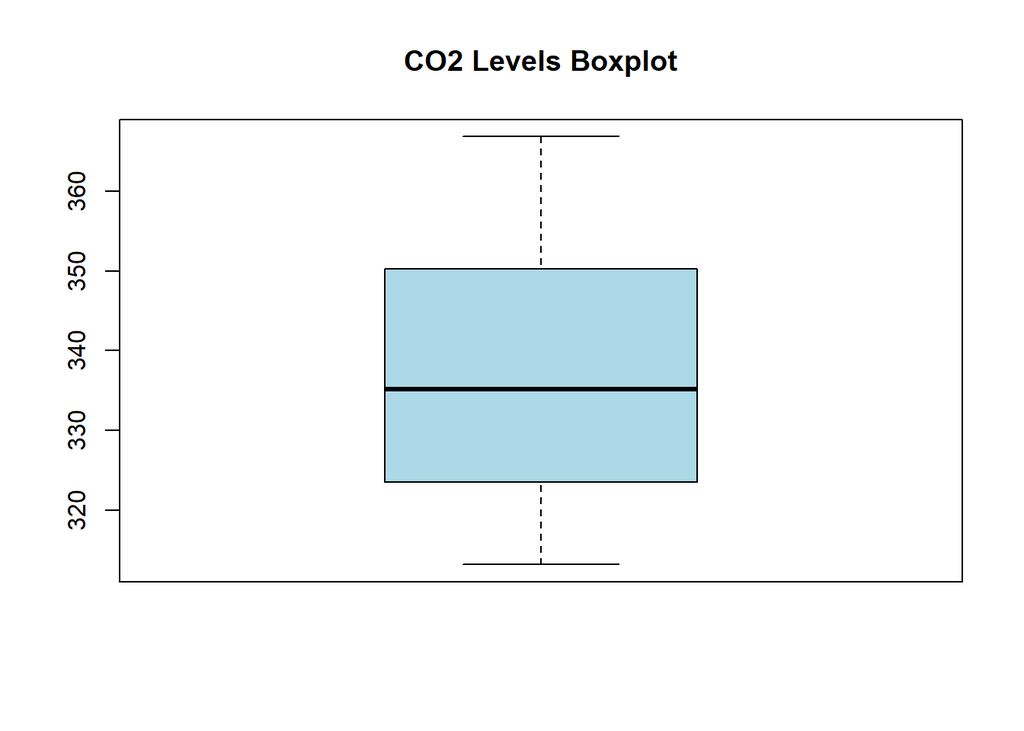

```r
boxplot(co2.df$y, main="CO2 Levels Boxplot", col="lightblue")
```

## 5.4 Interpretation

This boxplot helps identify outliers and visualize the spread of CO₂ levels over time. The Boxplot gives a summary of:

Minimum Value = 313.2

1st Quartile = 323.5

Median = 335.2

Mean = 337.1

3rd Quartile = 350.3

Maximum Value = 366.8

Interquartile range = 26.8

## 5.5 Checking for Variance Instability

```r
library(lmtest)
# Breusch–Pagan Test for heteroscedasticity
bp_test <- bptest(lm(y ~ ds, data = co2.df))
print(bp_test)
```

```
##
##  studentized Breusch-Pagan test
##
## data:  lm(y ~ ds, data = co2.df)
## BP = 3.6164, df = 1, p-value = 0.05721
```

## 5.6 Interpretation

The Breusch-Pagan Test generates a p-value of 0.05721 (>0.05) therefore indicating homoscedasticity and thus not requiring a log transformation.

# Section 6: Conclusion

## 6.1 Writing equations

This is the equation that the prophet model uses for the additive regressive model.
$$y(t) = g(t) + s(t) + h(t) + \epsilon_t$$
where:

$g(t)$ is the trend component

$s(t)$ is the seasonal component

$h(t)$ is the holiday effect

$\epsilon_t$ is the error term

# References

- RStudio reference: https://rmarkdown.rstudio.com/lesson-1.html
- Source of co2 dataset:https://scrippsco2.ucsd.edu/data/atmospheric_co2/.